# Week 2 Worksheet Exercises

Escaping Flatland: Linear models and their limitations

## Aims

This session introduces simple and multiple linear regression models. You will be working with data from Österman (2021) to replicate parts their analysis. We will be covering only basic regression methods in this session, so the article will serve mainly as a broad background to the data here. We will be returning to this article in future weeks too, expanding our modelling strategy as we discover new methods. We will also practice some data management tasks and the basics of data visualisation using principles from ‘the **g**rammar of **g**raphics’ as implemented in the [`{ggplot2}`](https://ggplot2.tidyverse.org/) package (see Kieran Healy’s [*Data Visualization: A practical introduction*](https://socviz.co/) for an introduction with many practical examples).

By the end of the session, you will:

- learn how to import data from foreign formats (e.g. SPSS, Stata, CSV)
- know how to perform basic descriptive statistics on a dataset
- understand the basics of data visualisation
- know how to fit linear regression models in `R` using different functions
- learn a few options for presenting findings from regression models

## Setup

In Week 1 you set up `R` and `RStudio`, and an **RProject** folder (we called it “HSS8005_labs”) with an `.R` script and a `.qmd` or `.Rmd` document in it (we called these “Lab_1”). Ideally, you saved this on a cloud drive so you can access it from any computer (e.g. OneDrive). You will be working in this folder. If it’s missing, complete Exercise 3 from the Week 1 Worksheet.

You can create a new `.R` script and `.qmd`/`.Rmd` for this week’s work (e.g. “Lab_2”). Start working in the `.R` script initially, then switch to `.qmd`/`.Rmd` later in the session to report on your final analysis.

## Exercise 1: Load (and install) R packages needed for this lab

Using function we have learnt in Week 1, load (and install, if needed) the following R packages:

- [`tidyverse`](https://www.tidyverse.org/)
- [`easystats`](https://easystats.github.io/easystats/)
- [`gtsummary`](https://www.danieldsjoberg.com/gtsummary/index.html)
- [`ggformula`](https://www.mosaic-web.org/ggformula/index.html)
- [`sjlabelled`](https://strengejacke.github.io/sjlabelled/index.html)

## Exercise 2: Import external data

As we have seen in Week 1, small datasets that are included in R packages (including base R) for demonstration purposes can be used by simply invoking the name of the dataset. For example, the command `head(mtcars)` would print out the first 5 rows (cases) in the “mtcars” dataset included in base R (more specifically, in its “datasets” package). To access a dataset from a non-base-R package, the process is similar, however, we need to ensure that the package is installed on our system and that we specify the name of the package; for example, to access the `{starwars}` dataset (which contains all sorts of information about the characters of Star Wars films), we need to make sure that [dplyr](https://dplyr.tidyverse.org) - or the whole [tidyverse](https://tidyverse.tidyverse.org) - is installed:

```r
head(starwars) # gives an Error

head(dplyr::starwars) # works, as long as {dplyr} or the whole {tidyverse} are installed
```

Real-life datasets, however, need to be imported into R. Datasets come in various formats. R’s native data format has the extension `.rds` and can be imported with the `readRDS()` function. The counterpart function `saveRDS()` exports a dataset to the `.rds` format. The core-tidyverse [{readr}](https://readr.tidyverse.org/index.html) package has similar functions (`read_rds()` / `write_rds()`).

The `.rds` format is useful because it can be compressed to various sizes to take up less space, but can only be directly opened in `R`. It is much more common to encounter data saved in a “delimited” text format, which can be easily opened in a spreadsheet viewer/editor such as Excel. This makes it very interchangeable and therefore very common. The most common is probably the “comma separated values” (`.csv`) format, which can be imported with the base-R function `read.csv()` or the tidyverse `readr::read_csv()` equivalent. Read Chapter 11 in [R4DS](https://r4ds.had.co.nz/data-import.html) for more on these functions.

Very often, you will need to import data saved in the format of another proprietary statistical analysis package such as SPSS or Stata. Large survey projects usually make data available in these formats. The great advantage of these formats is that they can incorporate additional information about variables and the levels of categorical variables (e.g. value labels, specific values for different types of missing values). These additional information can be extremely valuable, but they are not handled straight-forwardly in text-based format, spreadsheets and R’s native data format. To make them operational in R, we need a few specially designed functions.

The [{haven}](https://haven.tidyverse.org/index.html) package — part of the extended {tidyverse}, meaning that it is installed on your system as part of {tidyverse}, but the `library("tidyverse")` command does not load it by default; it needs to be loaded explicitly — is one of the most commonly used for this purpose. Functions such as `read_sas()`, `read_sav()` and `read_dta()` import datasets specific to the SAS, SPSS and Stata programs, respectively.

It is highly recommended to read the documentation available for the [{haven}](https://haven.tidyverse.org/index.html) package to understand how it operates. Fundamentally, it is designed to import data to a intermediary format which stores the additional labeling information in a special format that allows users to access them, but not making them easy to use directly. A [suite of packages developed by Daniel Lüdecke](https://strengejacke.r-universe.dev/builds) from the University of Hamburg offer some additional functionality to work with labels directly when summarising and plotting data. These packages integrate well with the {tidyverse} and are actively maintained, and we will use them in this course to make our lives a bit easier.

In a previous step, we have installed and loaded the [{sjlabelled}](https://strengejacke.github.io/sjlabelled/index.html) package and the [easystats](https://easystats.github.io/easystats/) suite of packages, which includes the [datawizard](https://easystats.github.io/datawizard/) package that contains a number of functions that make data(frame) manipulations easier.

The functions `sjlabelled::read_sas()`, `sjlabelled::read_spss()` and `sjlabelled::read_stata()` are the {sjlabelled} equivalents of the {haven} functions mentioned above. [This vignette article](https://strengejacke.github.io/sjlabelled/articles/intro_sjlabelled.html) included with the package explains the main differences between the two.

The more generic function `data_read()` from [easystats](https://easystats.github.io/easystats/)’s [datawizard](https://easystats.github.io/datawizard/) package loads data from various formats based on the source files extension, including files from internet sources or compressed files. It relies on the rio package, which provides similar functionality.

**Tip**

**It’s important** to note that by default the `data_read()` function assumes that numeric variables where all values have a value label are categorical and will convert them into *factors*. That means that all the numeric “values” will be replaced by the “value labels” (e.g. 1=“Yes”/ 2=“No” will become simply “Yes”/“No”).

This is usually a reasonable default behaviour, because the majority of functions in `R` do not handle “value labels” and working with textual (character string) values can be more explicit.

However, this may be less appropriate when the dataset contains many long ordered variables (such as 0-10 scale items), as we will most likely want to treat such variables as *numeric* in statistical models. To cancel this default behaviour, we can add the additional argument `convert_factors = FALSE`. This is also the format that gets imported when using `readRDS()`.

However, most of the common tabulation and graphing functions will not show the category “labels” in the output either, and for that purpose having variables “converted to factors” (with the original “Values” overwritten by the “Value labels”) may be a better option.

As a first step, let’s import the **osterman** dataset that underpins the Österman (2021) article (see the [Data page](https://cgmoreh.github.io/HSS8005-24/data/) on the course website for information about the datasets available in this course):

```r
osterman <- datawizard::data_read("https://cgmoreh.github.io/HSS8005-data/osterman.dta")
```

## Exercise 3: Summarise dataset and create a codebook

Using functions learnt in Week 1, do the following:

1. check the dimensions of the dataset; what does it tell you?
2. print a summary of the entire dataset; what have you learnt about the data?

There are various other options available for describing variables in different packages. For example, the `describe_distribution()` function from the [datawizard](https://easystats.github.io/datawizard/) package which is part of the [easystats](https://easystats.github.io/easystats/) ecosystem that we already installed and loaded is useful for summarising *numeric* variables, while the `data_tabulate()` is useful for creating frequency tables of *categorical* variables.

Run the commands below and inspect the outputs:

```r
describe_distribution(osterman)
```

A very convenient way to create a codebook for a dataset – especially if it has value-labelled categorical variables – is offered by `datawizard::data_codebook()` function. The generated codebook describes the variables in the dataset and provides brief summary statistics. We can view this codebook in the RStudio Viewer, or we can save it as an html file. Codebooks are very useful for gaining an overview understanding of a large dataset.

In the command below we create an object storing the codebook; once it’s created, open the codebook in the Viewer and inspect it:

```r
osterman_codebook <- data_codebook(osterman)
```

## Exercise 4: Descriptive graphs

Create some basic descriptive graphs using the `ggplot()` command from the {ggplot2} tidyverse package for the association between the following variables:

1. ‘trustindex3’ and ‘eduyrs25’
2. ‘trustindex3’ and ‘agea’
3. ‘trustindex3’ and ‘female’

### 1. ‘trustindex3’ and ‘eduyrs25’

The best way to approach this problem is by working through the first examples in Kieran Healy’s [*Data Visualization: A practical introduction*](https://socviz.co/), starting at Chapter 3, and applying them to your data. Outside class, you can develop these basic graphs into better looking ones by adding various extra layers. The `ggplot()` function is part of the [ggplot2](https://ggplot2.tidyverse.org) package, which is included in the core [tidyverse](https://tidyverse.tidyverse.org), so we don’t need to load it separately if we have already loaded the tidyverse.

The `ggplot` approach to graphs is to build them up step-by-step using various layers. The basic template code for a `ggplot()` graph is the following:

```
ggplot(data = <DATA>, mapping = aes(<MAPPINGS>)) +  <GEOM_FUNCTION>()
```

For example, the code below sets up a totally blank canvas:

```r
ggplot()
```

To start populating the canvas we need to add a first layer containing our dataset and the variables we want to ‘map’ using the `aes()` argument (for “aesthetic mapping”). This adds coordinates to the canvas based on the variables we want to graph (in our case, ‘trustindex3’ and ‘eduyrs25’). We are treating ‘trustindex3’ as the outcome variables in these exercises, so we will want to position it on the `y` axis:

```r
ggplot(osterman, aes(y = trustindex3, x = eduyrs25))
```

We now have a basic layer, but no actual data. The final crucial move is to add another layer using the `+` operator the type of graph (called a “geom” in ggplot, short for “geometric object”, such as a bar, a line, a boxplot, histogram, etc.) that we want to use to represent the relationship between the two variables. In this case, given that both variables are measured on a *numeric* scale (or at least on an *ordinal* scale with seven or more categories), the best option is a **scatterplot**. In `ggplot()`, a scatterplot “geom” are called with the `geom_point()` function:

```r
ggplot(osterman, aes(y = trustindex3, x = eduyrs25)) +
  geom_point()
```

We now have a scatterplot of the relationship between ‘trustindex3’ and ‘eduyrs25’. Because our scales are rather short and the data is spread out, this scatterplot is not very informative.

We can choose to add another “geom” that is better able to summarise the relationship. The function `geom_jitter()` (a shortcut to the specification `geom_point(position = "jitter")`) is helpful in such cases because it adds a small amount of random variation to the location of each point, making areas of overlapping points more visible. The commands below do the same thing:

```r
ggplot(osterman, aes(y = trustindex3, x = eduyrs25)) +
  geom_point(position = "jitter")
```

```r
ggplot(osterman, aes(y = trustindex3, x = eduyrs25)) +
  geom_point() +
  geom_jitter()
```

```r
ggplot(osterman, aes(y = trustindex3, x = eduyrs25)) +
  geom_jitter()
```

Another option is the `geom_smooth()` function, which provides a set of options, basically returning “smooth lines” representing various types of regression lines. The function fits a regression in the background and graphs the results. The default setting is to fit a *generalized additive model* that captures non-linearities in the data with a *smoothing spline* (the Wikipedia article on [GAMs](https://en.wikipedia.org/wiki/Generalized_additive_model) gives a maths-heavy outline of these models, but they are beyond our interests here). The smooth line produced is probably more informative about the general idea:

```r
ggplot(osterman, aes(y = trustindex3, x = eduyrs25)) +
  geom_jitter() +
  geom_smooth()
```

But we can also specify other regression methods, and because we are here aiming to model the relationship between *trust* and *education* as a linear model, we can specify the method as “lm”:

```r
ggplot(osterman, aes(y = trustindex3, x = eduyrs25)) +
  geom_jitter() +
  geom_smooth(method = "lm")
```

```r
ggplot(osterman, aes(y = trustindex3, x = eduyrs25)) +
  geom_jitter(alpha = 0.1) +
  geom_smooth(method = "lm", colour = "red")
```

### 2. ‘trustindex3’ and ‘agea’

We can now do something similar for the relationship between *trust* and *age* (the ‘trustindex3’ and ‘agea’ variables in the dataset). Again, both variables are measured on a *numeric* scale, so a scatterplot should work best. Because we don’t know what to expect and therefore what additional settings would improve each individual graph, we start from the most basic informative layer and build up from there. To practice some alternative approaches to working with plots, here we will first save the basic plot as a **ggplot object**, to which we can later add further layers and specifications:

```r
age_plot <- ggplot(osterman, aes(y = trustindex3, x = agea)) +
  geom_point()
```

If no output was generated from the command above, that’s as expected. The graph was produced, but we didn’t ask for it to be printed, we only asked for it to be saved as an object called “age_plot”. To see it, we can simply call “age_plot”. We can then make various additions to this plot.

```r
age_plot
```

This looks very similar to the previous graph, so we could add the same additional specificaitons as in the previous exercise, this time to the plot object that we saved:

```r
age_plot +
  geom_jitter(alpha = 0.1) +
  geom_smooth(method = "lm", colour = "red")
```

### 3. ‘trustindex3’ and ‘female’

We can try a similar scatterplot here too, but there may be better options:

```r
ggplot(osterman, aes(y = trustindex3, x = female)) +
  geom_point() +
  geom_jitter(alpha = 0.1) +
  geom_smooth(method = "lm", colour = "red")
```

This graph can be confusing, are we are better off using another “geom” because the *female* variable is a dichotomous/binary factor (categorical) variable. A good visualisation tool in the this case is a boxplot, which can be called with the `geom_boxplot()` function:

```r
ggplot(osterman, aes(y = trustindex3, x = female)) +
  geom_boxplot()
```

The issue with this graph is that the **female** variable, while a *dichotomous*/*binary* *categorical* variable, is not labelled; instead, the value `1` is taken to represent the “true” value for the name of the variable (i.e. `1` means that one is *female*, as the variable name states, and the value `0` means that they are not female, but *male*).

We could use the `set_labels()` function from the [sjlabelled](https://strengejacke.github.io/sjlabelled/) package to add labels to this variable:

```r
osterman <- osterman |>
  sjlabelled::set_labels(female, labels = c("Male", "Female"))
```

The [sjlabelled](https://strengejacke.github.io/sjlabelled/) package also has a special variable type - `as_label()` - which is useful for forcing `R` to use the *labels* of factor variables in outputs. In the command below, we first change the variable type with `as_label()`, then we run the same `ggplot(_)` function as before:

```r
# We are overwriting the original dataset here, so we better not make a mistake:
osterman <- osterman |> mutate(female = sjlabelled::as_label(female))

# And from now on the 'female' variable will be treated as a labelled factor:
ggplot(osterman, aes(y = trustindex3, x = female)) +
  geom_boxplot()
```

Box-plots contain a lot of useful summary information about variables, and the interpretation of the shapes is the following:

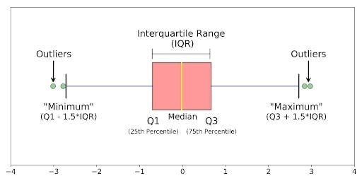

box-plot

## Exercise 5: Fit simple bivariate regression models using OLS

Fit three simple bivariate OLS regressions using the `lm()` function:

1. Regress ‘trustindex3’ on ‘eduyrs25’ and interpret the results
2. Regress ‘trustindex3’ on ‘agea’ and interpret the results
3. Regress ‘trustindex3’ on ‘female’ and interpret the results
4. Regress ‘trustindex3’ on all three predictors listed above and interpret the results

### 1. Regress ‘trustindex3’ on ‘eduyrs25’ and interpret the results

We will do just that, saving the regression as an object called “m1” (for *model 1*):

```r
m1 <- lm(trustindex3 ~ eduyrs25, data = osterman)
```

The model object has now been saved in the Environment, and we can inspect it manually if we want by opening it in the Source window. The object is a large list, with various components that we can call and print separately. The most basic information that we can obtain from the model is the coefficients:

```r
coefficients(m1)
```

This basic information is enough to solve the linear equation underpinning the model:

We can also get more information about the model with the `summary()` function. When applied to a linear model object, it provides the following output:

```r
summary(m1)
```

This output tells us a lot more about the fitted model, for example a summary table of the residuals and an analysis of variance (ANOVA) summary of the residuals, as well as estimates of variation for our coefficients (the standard errors and the p-values associated with t-tests - displayed as *Pr(>|t|)*).

While these are informative, the format is not ideal for further manipulation and presentation. Several user-written functions exist to improve on this output. For example, the [`{broom}`](https://broom.tidymodels.org/) package - part of the [`{tidymodels}`](https://www.tidymodels.org/) suite of packages - has functions to extract model information into “tidy” tibbles (data sets), which can then be further manipulated and plotted. This is especially useful when working with results from many models that would benefit from comparing in a standardised format.

The `summary()` function prints out a lot of information, but it’s not the best format if we wish to reuse the various statistical components for further analysis, and the presentation of the output could also be improved. The `model_parameters()` and the `model_performance()` functions from the [parameters](https://easystats.github.io/parameters/) package part of [easystats](https://easystats.github.io/easystats/) is a better option:

```r
model_parameters(m1)

model_performance(m1)
```

The output table shows both 95% confidence intervals (CI) and the standard errors (SE), which can be easier to interpret (CI are calculated as *Estimate +/- (1.96 x Std. Error)*; you can try it out in the Console, replacing in the numeric values).

The best approach is to graph the model results and present them in a figure, but that’s not very informative in the case of a simple model with only one predictor, so we can leave it for later.

### 2. Regress ‘trustindex3’ on ‘agea’ and interpret the results

We can do as above:

```r
# Write your own code; name the mode "m2"
```

### 3. Regress ‘trustindex3’ on ‘female’ and interpret the results

```r
# Write your own code; name the model "m3"
```

### 4. Regress ‘trustindex3’ on all three predictors listed above and interpret the results

Finally we can fit a multiple linear model with several predictors:

```r
# Write your own code; name the model "m4"
```

```r
sample <- m4$model

m3_new <- lm(trustindex3 ~ female, data = sample)

model_parameters(m3)
```

## Exercise 6 (Advanced): Apply the model to a new dataset

You should already be familiar with the functions needed to complete each of these steps, but it may require some self-study. The most important *missing information* required to complete this exercise is to be found in the description on how the **trustindex3** scale was computed:

> To study generalized social trust, I am following the established approach of using a validated three-item scale (Reeskens and Hooghe 2008; Zmerli and Newton 2008). This scale consists of the classic trust question, an item on whether people try to be fair, and an item on whether people are helpful:  
> - ‘Generally speaking, would you say that most people can be trusted, or that you can’t be too careful in dealing with people?’  
> - ‘Do you think that most people would try to take advantage of you if they got the chance, or would they try to be fair?’  
> - ‘Would you say that most of the time people try to be helpful or that they are mostly looking out for themselves?’  
> All of the items may be answered on a scale from 0 to 10 (where 10 represents the highest level of trust) and the scale is calculated as the mean of the three items. The three-item scale clearly improves measurement reliability and cross-country validity compared to using a single item, such as the classic trust question. … See the Supplementary material for additional information on the construction of the social trust scale (Section A.1), as well as for models using the classic single-item measure of trust (Section A.9).

<< the end >>

## References

Österman, Marcus. 2021. “Can We Trust Education for Fostering Trust? Quasi-experimental Evidence on the Effect of Education and Tracking on Social Trust.” *Social Indicators Research* 154 (1): 211–33. https://doi.org/10.1007/s11205-020-02529-y.